# 6. Analysis of longitudinal data

### Linear Mixed Effects models

As the regular linear model is not very informative in this case because of the data, intercept is allowed to vary for each individual in the random intercept model below. This is something very nice called linear mixed effects model. Later on there are more variations to this.

```r
bprsl_ref <- lmer(bprs ~ week + treatment + (1 | subject), data = BPRSL, REML = FALSE)
summary(bprsl_ref)
```

```
## Linear mixed model fit by maximum likelihood  ['lmerMod']
## Formula: bprs ~ week + treatment + (1 | subject)
##    Data: BPRSL
##
##      AIC      BIC   logLik deviance df.resid
##   2748.7   2768.1  -1369.4   2738.7      355
##
## Scaled residuals:
##     Min      1Q  Median      3Q     Max
## -3.0481 -0.6749 -0.1361  0.4813  3.4855
##
## Random effects:
##  Groups   Name        Variance Std.Dev.
##  subject  (Intercept)  47.41    6.885
##  Residual             104.21   10.208
## Number of obs: 360, groups:  subject, 20
##
## Fixed effects:
##             Estimate Std. Error t value
## (Intercept)  46.4539     1.9090  24.334
## week         -2.2704     0.2084 -10.896
## treatment2    0.5722     1.0761   0.532
##
## Correlation of Fixed Effects:
##            (Intr) week
## week       -0.437
## treatment2 -0.282  0.000
```

From the summary one can see the variances of subjects and the correlation of fixed effects. Compared to the regular linear model, the coefficients are the same, but the standard errors for “week” and “treatment” are smaller.

Next, both random intercept and random slope are used in the linear model. This allows for the fit of the model for each individual in the data to differ in intercept and in slope. This is used to allow the model to adjust for the individual differences in the subjects’s bprs values and for the different developments during the period.

```r
#Linear mixed effects model with random slope and random intercept
BPRS_ref1<- lmer(bprs ~ week + treatment +(week | subject), data=BPRSL, REML=FALSE)
summary(BPRS_ref1)
```

```
## Linear mixed model fit by maximum likelihood  ['lmerMod']
## Formula: bprs ~ week + treatment + (week | subject)
##    Data: BPRSL
##
##      AIC      BIC   logLik deviance df.resid
##   2745.4   2772.6  -1365.7   2731.4      353
##
## Scaled residuals:
##     Min      1Q  Median      3Q     Max
## -2.8919 -0.6194 -0.0691  0.5531  3.7976
##
## Random effects:
##  Groups   Name        Variance Std.Dev. Corr
##  subject  (Intercept) 64.8202  8.0511
##           week         0.9608  0.9802   -0.51
##  Residual             97.4307  9.8707
## Number of obs: 360, groups:  subject, 20
##
## Fixed effects:
##             Estimate Std. Error t value
## (Intercept)  46.4539     2.1052  22.066
## week         -2.2704     0.2977  -7.626
## treatment2    0.5722     1.0405   0.550
##
## Correlation of Fixed Effects:
##            (Intr) week
## week       -0.582
## treatment2 -0.247  0.000
```

Lastly, the LME model is performed with random slope and random intercept and time*group interaction.

```r
#Linear mixed effects model with random slope and random intercept and time*group interaction
BPRS_ref2<- lmer(bprs ~ week*treatment+(week | subject), data=BPRSL, REML=FALSE)
summary(BPRS_ref2)
```

```
## Linear mixed model fit by maximum likelihood  ['lmerMod']
## Formula: bprs ~ week * treatment + (week | subject)
##    Data: BPRSL
##
##      AIC      BIC   logLik deviance df.resid
##   2744.3   2775.4  -1364.1   2728.3      352
##
## Scaled residuals:
##     Min      1Q  Median      3Q     Max
## -3.0512 -0.6271 -0.0767  0.5288  3.9260
##
## Random effects:
##  Groups   Name        Variance Std.Dev. Corr
##  subject  (Intercept) 65.0016  8.0624
##           week         0.9688  0.9843   -0.51
##  Residual             96.4699  9.8219
## Number of obs: 360, groups:  subject, 20
##
## Fixed effects:
##                 Estimate Std. Error t value
## (Intercept)      47.8856     2.2522  21.262
## week             -2.6283     0.3589  -7.323
## treatment2       -2.2911     1.9090  -1.200
## week:treatment2   0.7158     0.4010   1.785
##
## Correlation of Fixed Effects:
##             (Intr) week   trtmn2
## week        -0.650
## treatment2  -0.424  0.469
## wek:trtmnt2  0.356 -0.559 -0.840
```

ANOVA for random intercept random slope model vs the random slope and random intercept and time*group interaction model. ANOVA suggests that the lower the p-value, the better the fit against the comparison model. Now, depending on where we set the significance level, let’s say it’s 10%, we can conclude that the model with the interaction term (BPRS_ref2) has better fit than the model without it (BPRS_ref1).

```r
anova(BPRS_ref2, BPRS_ref1)
```

```
## Data: BPRSL
## Models:
## BPRS_ref1: bprs ~ week + treatment + (week | subject)
## BPRS_ref2: bprs ~ week * treatment + (week | subject)
##           Df    AIC    BIC  logLik deviance  Chisq Chi Df Pr(>Chisq)
## BPRS_ref1  7 2745.4 2772.6 -1365.7   2731.4
## BPRS_ref2  8 2744.3 2775.4 -1364.1   2728.3 3.1712      1    0.07495 .
## ---
## Signif. codes:  0 '***' 0.001 '**' 0.01 '*' 0.05 '.' 0.1 ' ' 1
```

Following the DataCamp exercise, the last thing in this chapter is to plot the actual data and the fitted data for both groups (treatment = 1 (LHS) vs treatment = 2 (RHS)). Like earlier, each individual is represented by it’s own line (and color).

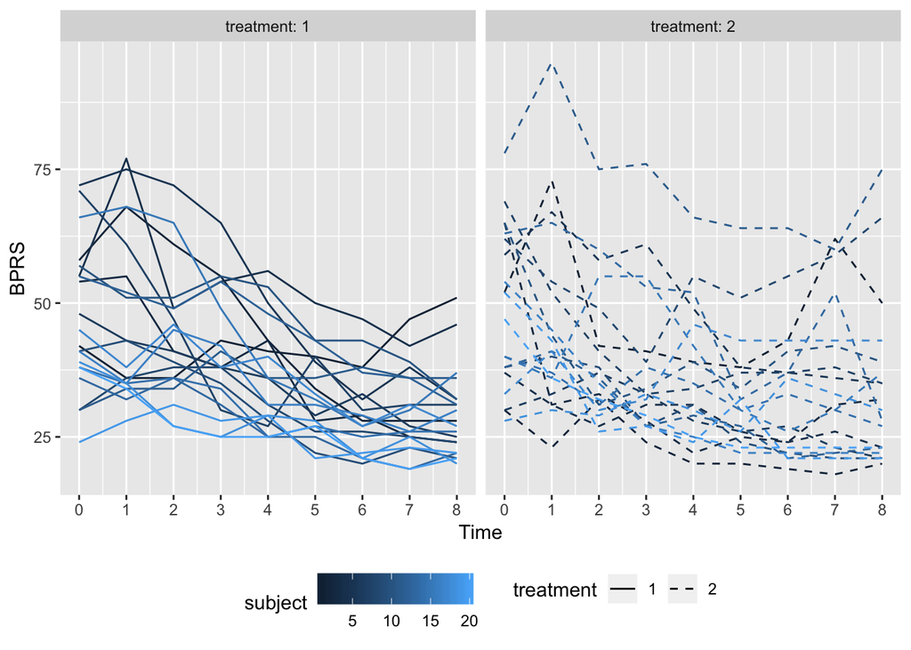

```r
Fitted <- fitted(BPRS_ref2)
BPRSL <- BPRSL %>% mutate(Fitted)
BPRSL <- mutate(BPRSL, subject2 = ifelse(BPRSL$treatment==2, BPRSL$subject+20, BPRSL$subject))


ggplot(BPRSL, aes(x = week, y = bprs, group = subject2,col= subject)) +
  geom_line(aes(linetype = treatment)) +
  scale_linetype_manual(values = rep(1:10, times=4)) +
  facet_grid(. ~ treatment, labeller = label_both) +
  scale_x_continuous(name = "Time", breaks = seq(0, 8, 1)) +
  scale_y_continuous(name = "BPRS") +
  theme(legend.position = "bottom")
```

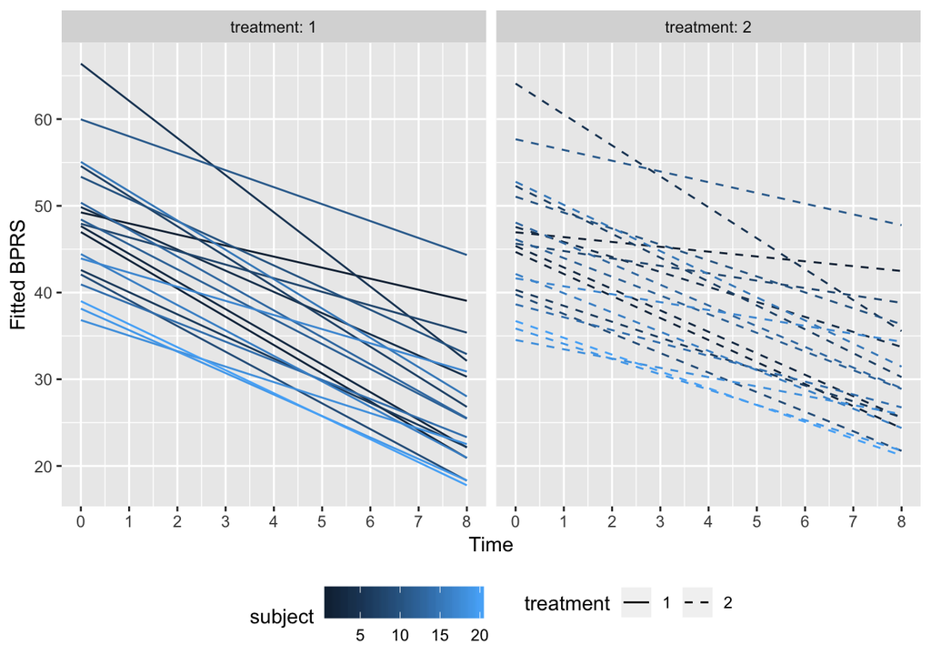

```r
ggplot(BPRSL, aes(x = week, y = Fitted, group = subject2, col= subject)) +
  geom_line(aes(linetype = treatment)) +
  scale_linetype_manual(values = rep(1:10, times=4)) +
  facet_grid(. ~ treatment, labeller = label_both) +
  scale_x_continuous(name = "Time", breaks = seq(0, 8, 1)) +
  scale_y_continuous(name = "Fitted BPRS") +
  theme(legend.position = "bottom")
```